# Supplementary Information: Models

Laura Geronimo

## Full Sample Variable Selection Procedure

### SVSS test

Running SVSS test to see which variables are included

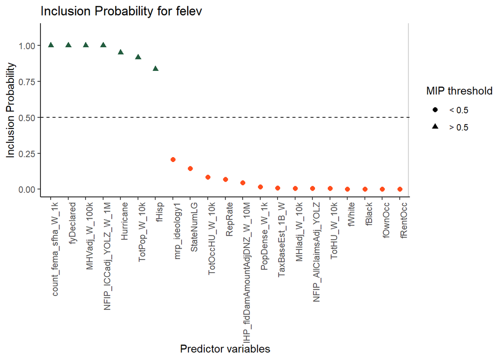

### Correlation Matrices on select vars

Note that in preparation for modeling, we examine all of the variables recommended in the SVSS test, plus variables that were significant in the Chi-Square and Anova tests, and are relevant to the literature based on domain knowledge.

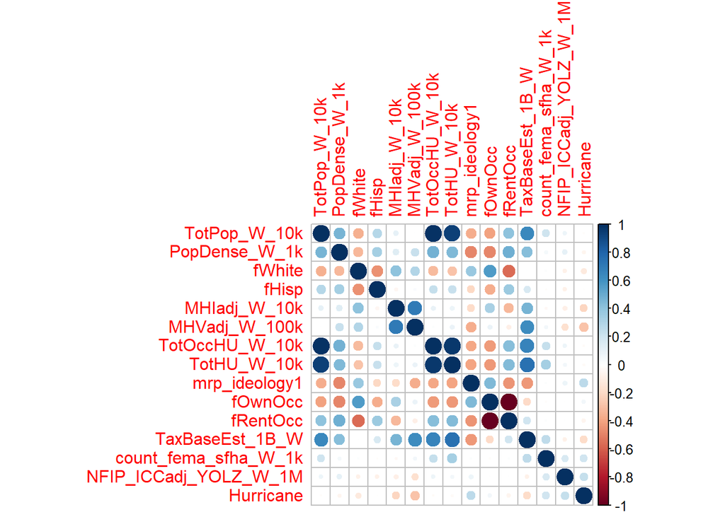

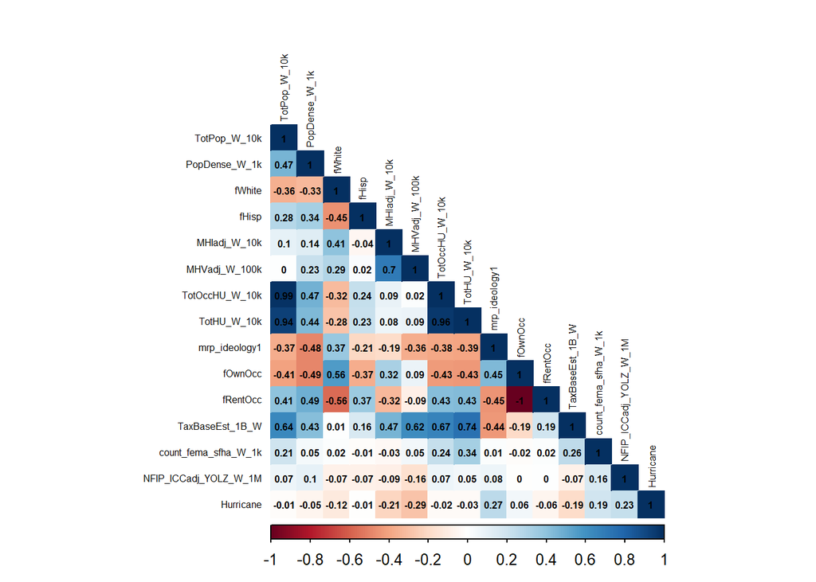

Given the high correlation between MHV and MHI, we drop MHI.

Some notes: -MPR ideology is negatively correlated with MHV: as MHV increase, republican ideology decreases (suggests lower-income is correlated with republicanism) -Tax base and MHV are positively correlated. Dropping Tax Base

##Stepwise Regression

## Model 1: All hypotheses

##### Correlation Matrices for M1

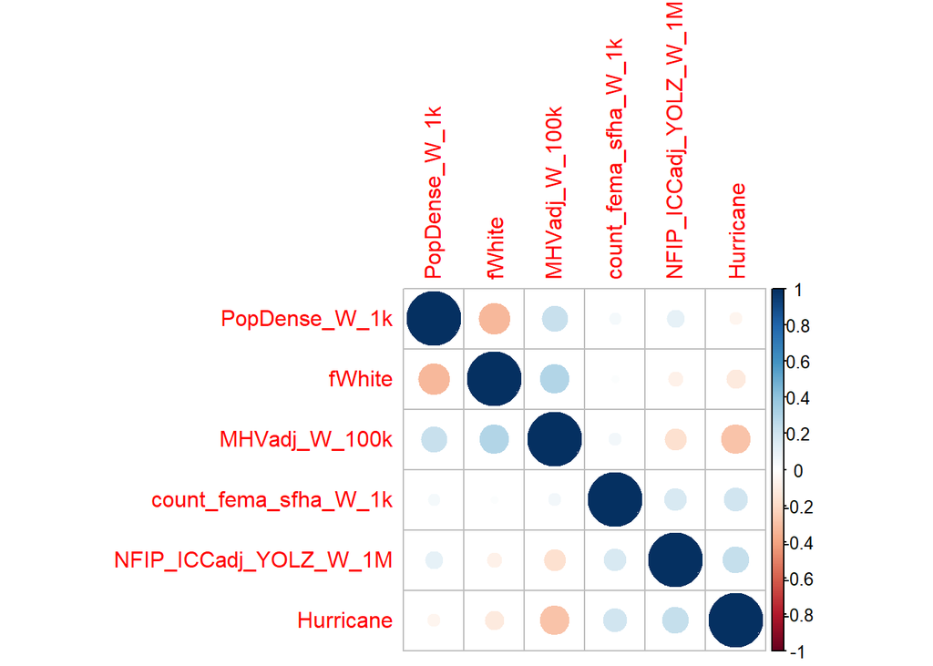

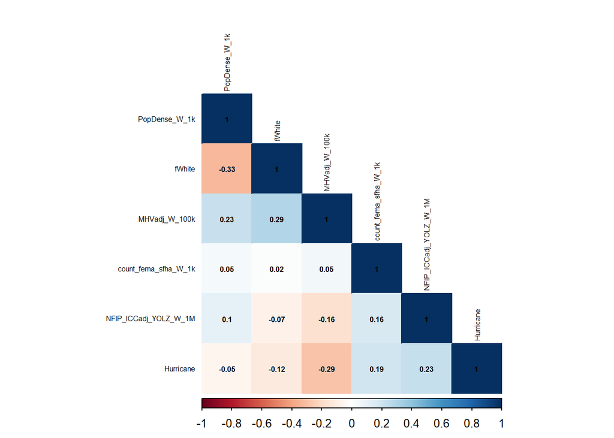

Based on analysis of the correlation matrix, we retain all variables. Next we run a model without Fixed effects and check the VIF scores.

##### M1 - Full model without fixed effects & select vars -checking VIF

###### VIF

```
##         MHVadj_W_100k                fWhite             Hurricane
##              1.383871              1.341459              1.170948
##  count_fema_sfha_W_1k NFIP_ICCadj_YOLZ_W_1M         PopDense_W_1k
##              1.046735              1.085926              1.359158
```

The results of the VIF suggest that all of these variables are ok to include for M1. Now adding fixed effects, as well as an interaction term on fWhite and MHV. Then we run the stepwise procedure to select the final model.

##### M1 - Full model with fixed effects & select vars

###Running stepwise to obtain final model for analysis

The stepwise procedure identifies a model that includes 4 variablesand fixed effects.

##### M1_SW: M1 stepwise model & diagnostics

**Logit Model 1B: Full sample (testing Race and MHV**

|  | *Dependent variable:* |
| --- | --- |
|  | odds Ratio of felev |
| MHV (100k W) | 1.18** |
|  | (0.08) |
| Fraction White | 3.94*** |
|  | (0.37) |
| Count of HUs in FEMA SFHA 1k (W) | 1.17*** |
|  | (0.04) |
| NFIP ICC Claims 1M (W) by ZCTA-YOL | 1.44*** |
|  | (0.14) |
| Constant | 8,931,764.00 |
|  | (2,399.54) |
| State FE | YES |
| Year FE | YES |
| Pseudo R2 | 0.31 |
| Observations | 1,321 |
| Log Likelihood | -630.12 |
| Akaike Inf. Crit. | 1,376.25 |
| *Note:* | p<0.1; p<0.05; p<0.01 |

##### M1 Series A.0: Single variable model all explanatory vars, with Fixed Effects:

**Logit Model Comparison: Single Variable Mode**

|  | *Dependent variable:* |  |  |  |  |
| --- | --- | --- | --- | --- | --- |
|  | odds Ratio of felev |  |  |  |  |
|  | (1) | (2) | (3) | (4) | (5) |
| MHV (100k W) |  | 1.35*** |  |  |  |
|  |  | (0.08) |  |  |  |
| Fraction White |  |  | 5.03*** |  |  |
|  |  |  | (0.35) |  |  |
| Count of HUs in FEMA SFHA 1k (W) |  |  |  | 1.21*** |  |
|  |  |  |  | (0.04) |  |
| NFIP ICC Claims 1M (W) by ZCTA-YOL |  |  |  |  | 1.58*** |
|  |  |  |  |  | (0.14) |
| Constant | 78,280,059.00 | 38,496,924.00 | 14,411,539.00 | 54,277,907.00 | 74,254,350.00 |
|  | (2,399.55) | (2,399.54) | (2,399.55) | (2,399.54) | (2,399.54) |
| State FE | YES | YES | YES | YES | YES |
| Year FE | YES | YES | YES | YES | YES |
| Pseudo R2 | 0.27 | 0.28 | 0.28 | 0.29 | 0.28 |
| Observations | 1,321 | 1,321 | 1,321 | 1,321 | 1,321 |
| Log Likelihood | -660.54 | -653.73 | -648.69 | -645.73 | -654.51 |
| Akaike Inf. Crit. | 1,429.09 | 1,417.46 | 1,407.38 | 1,401.45 | 1,419.03 |
| *Note:* | p<0.1; p<0.05; p<0.01 |  |  |  |  |

##### M1 Series A.1 (Starting with best model from above and dropping vars)

**Logit Model Comparison: Full Sample, Dropping variables**

|  | *Dependent variable:* |  |  |  |  |
| --- | --- | --- | --- | --- | --- |
|  | Odds Ratio of felev |  |  |  |  |
|  | (1) | (2) | (3) | (4) | (5) |
| MHV (100k W) | 1.18** |  | 1.28*** | 1.22** | 1.19** |
|  | (0.08) |  | (0.08) | (0.08) | (0.08) |
| Fraction White | 3.94*** | 4.87*** |  | 4.09*** | 3.69*** |
|  | (0.37) | (0.36) |  | (0.37) | (0.36) |
| Count of HUs in FEMA SFHA 1k (W) | 1.17*** | 1.18*** | 1.17*** |  | 1.19*** |
|  | (0.04) | (0.04) | (0.04) |  | (0.04) |
| NFIP ICC Claims 1M (W) by ZCTA-YOL | 1.44*** | 1.46*** | 1.40** | 1.58*** |  |
|  | (0.14) | (0.14) | (0.14) | (0.14) |  |
| Constant | 8,931,764.00 | 10,359,859.00 | 30,688,222.00 | 10,480,313.00 | 9,577,214.00 |
|  | (2,399.54) | (2,399.54) | (2,399.54) | (2,399.55) | (2,399.54) |
| State FE | YES | YES | YES | YES | YES |
| Year FE | YES | YES | YES | YES | YES |
| Pseudo R2 | 0.31 | 0.3 | 0.3 | 0.3 | 0.3 |
| Observations | 1,321 | 1,321 | 1,321 | 1,321 | 1,321 |
| Log Likelihood | -630.12 | -631.52 | -638.07 | -639.68 | -633.87 |
| Akaike Inf. Crit. | 1,376.25 | 1,377.04 | 1,390.14 | 1,393.36 | 1,381.74 |
| *Note:* | p<0.1; p<0.05; p<0.01 |  |  |  |  |

The model above confirms that the stepwise process selected the model with the lowest AIC

##### Post Tests M1

##### Examining outliers and leverage points

###### Diagnostics:

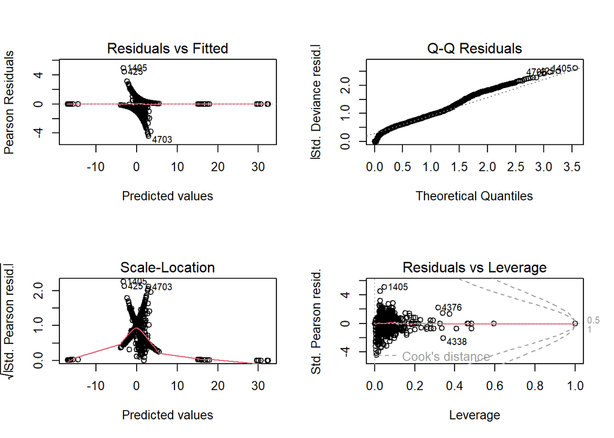

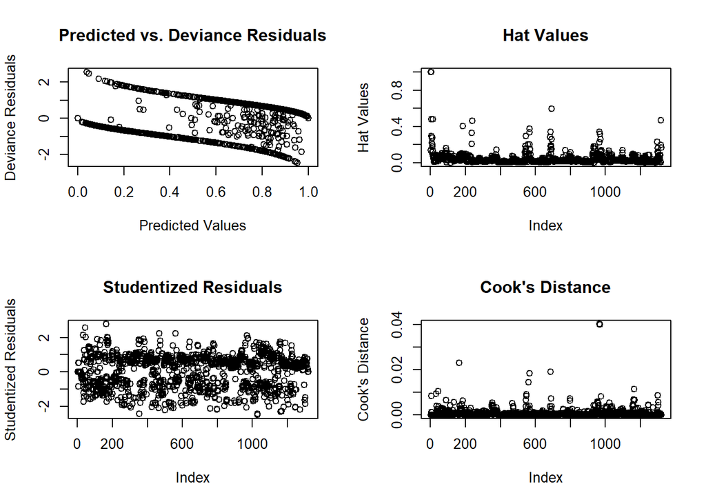

```
## No Studentized residuals with Bonferroni p < 0.05
## Largest |rstudent|:
##      rstudent unadjusted p-value Bonferroni p
## 1405 2.780014          0.0054357           NA
```

######Identifying influential observations

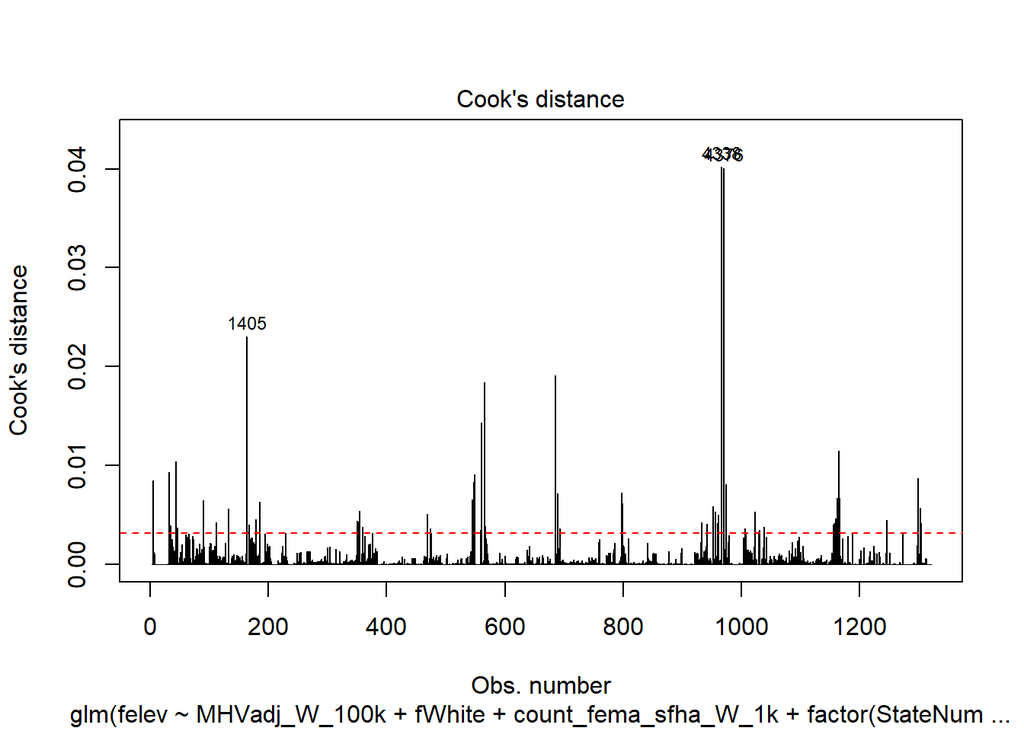

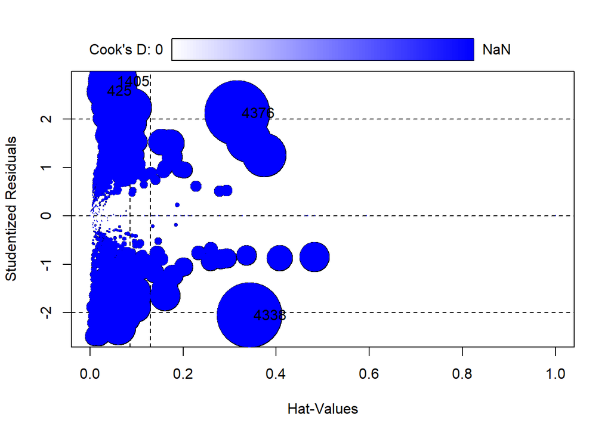

```
##        StudRes        Hat      CookD
## 4          NaN 1.00000000        NaN
## 24         NaN 1.00000000        NaN
## 425   2.579030 0.02812098 0.01037770
## 1405  2.780014 0.04849053 0.02303947
## 4338 -2.055405 0.34265465 0.04022498
## 4376  2.123020 0.31660488 0.04003399
```

### M1_Unlev: Dropping leverage points and rerunning model

**Logit Model Comparison: Dropping Influential Observations**

|  | *Dependent variable:* |
| --- | --- |
|  | Odds Ratio of felev |
| MHV (100k W) | 1.18** |
|  | (0.08) |
| Fraction White | 3.93*** |
|  | (0.37) |
| Count of HUs in FEMA SFHA 1k (W) | 1.17*** |
|  | (0.04) |
| NFIP ICC Claims 1M (W) by ZCTA-YOL | 1.46*** |
|  | (0.14) |
| Constant | 9,003,815.00 |
|  | (2,399.54) |
| State FE | Yes |
| Year FE | Yes |
| Pseudo R2 | 0.31 |
| Observations | 1,318 |
| Log Likelihood | -628.47 |
| Akaike Inf. Crit. | 1,370.94 |
| *Note:* | p<0.1; p<0.05; p<0.01 |

##### Post Tests M1_unLev

##### Examining outliers and leverage points

###### Diagnostics

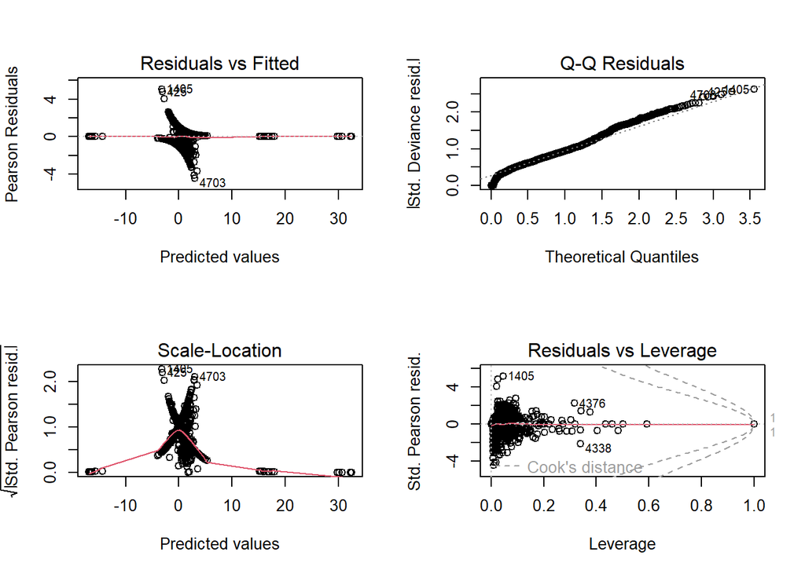

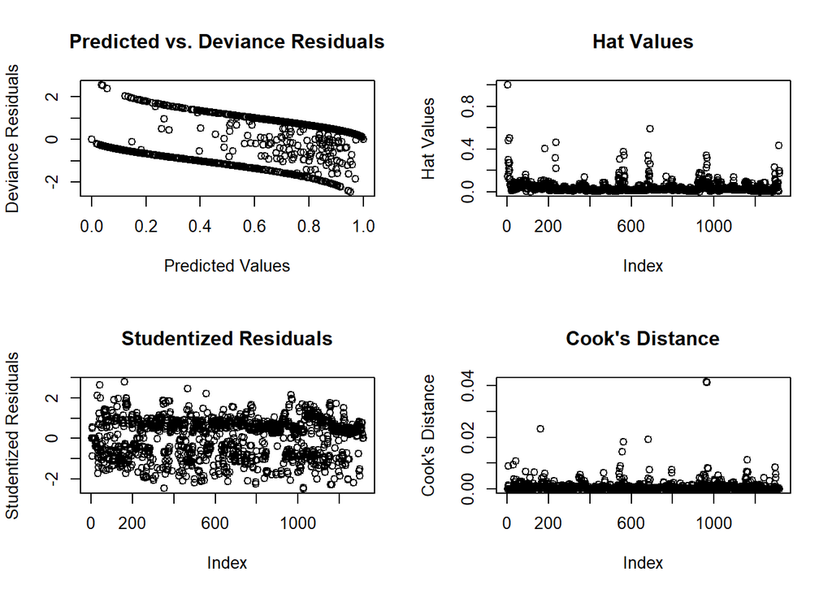

```
## No Studentized residuals with Bonferroni p < 0.05
## Largest |rstudent|:
##      rstudent unadjusted p-value Bonferroni p
## 1405 2.797899          0.0051436           NA
```

######Identifying influential observations

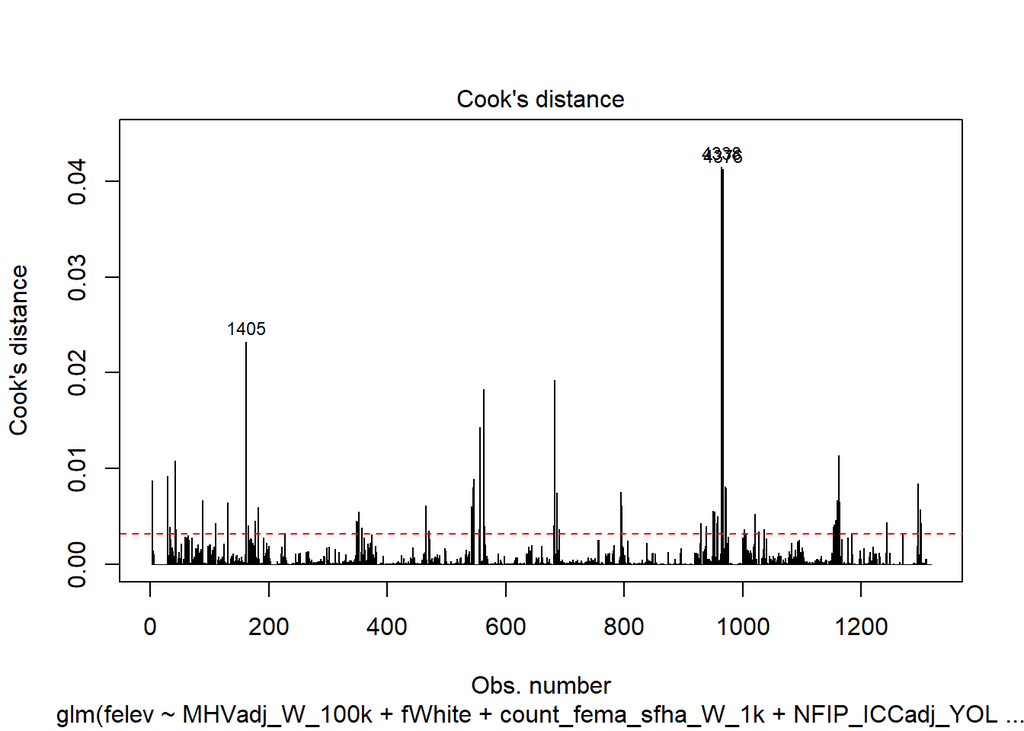

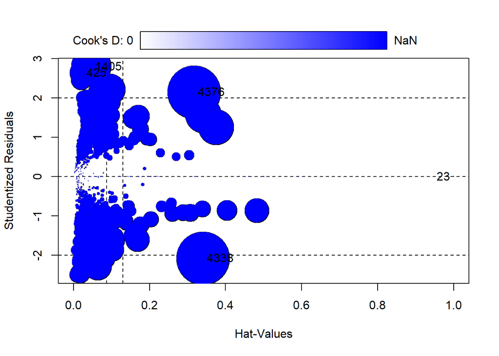

```
##                 StudRes        Hat                    CookD
## 4                   NaN 1.00000000                      NaN
## 23   -0.000000007965507 0.99999899 0.0000000000000001387413
## 425   2.638395015239814 0.02535968 0.0108004617520567128275
## 1405  2.797898540622069 0.04694012 0.0232502117690872069089
## 4338 -2.083290820954727 0.34092627 0.0415207375096189740260
## 4376  2.142632248376445 0.31739562 0.0412410681324176867091
```

###### Drawing predicted probabilities

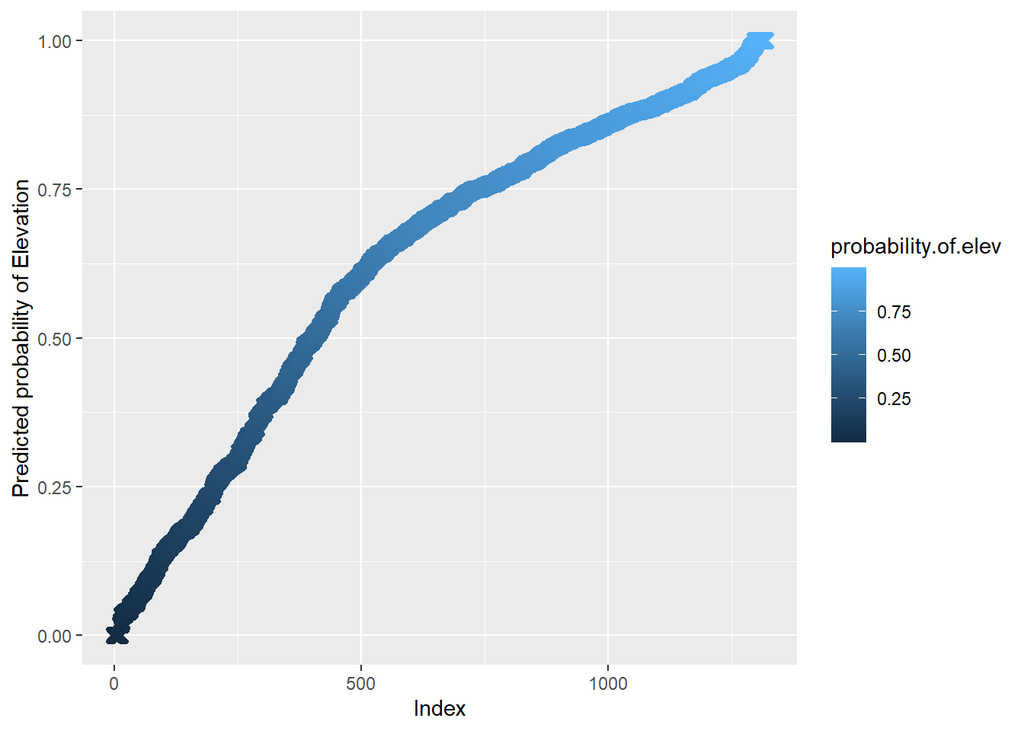

#### Logistic model comparing original Dissertation model with SVSS predictors